# Johns_Hopkins_Data_Analysis

2023-02-27

## Project Outline

1. We will import US COVID cases and deaths from the Johns Hopkins data set on github. This contains up to date data on COVID19 on both global and US cases and deaths. In this project, we will only be focusing on the US cases and deaths, not on the global cases and deaths.

https://raw.githubusercontent.com/CSSEGISandData/COVID-19/master/csse_covid_19_data/csse_covid_19_time_series/

2. We will clean up and prepare the data by removing unnecessary variables and suitably organizing it for our purposes.
3. We will summarize data by region i.e., Northeast, West, South, Midwest, and US Possessions and Cruise Ships.
4. The question we want to answer is what regional disparities, if any, exist in a) mortality rate and b) case mortality rate in the United States?
5. Based on the observed data, we will fit a model for case mortality rate in the US by state.

```r
library(tidyverse)
library(lubridate)
options(warn=-1)
```

### Read in US Cases and Deaths from github

```r
url_in <- "https://raw.githubusercontent.com/CSSEGISandData/COVID-19/master/csse_covid_19_data/csse_covid_19_time_series/"

file_names <- c("time_series_covid19_confirmed_global.csv","time_series_covid19_deaths_global.csv","time_series_covid19_confirmed_US.csv","time_series_covid19_deaths_US.csv")

urls <- str_c(url_in, file_names)

us_cases <- read_csv(urls[3])
us_deaths <- read_csv(urls[4])
```

### Clean Up the Data

```r
#Tidy up the data so that the cases and deaths for each date show up as a row

us_cases <- us_cases %>% pivot_longer(cols=-c(UID,'iso2','iso3',code3,FIPS,'Admin2','Province_State', 'Country_Region', Lat, Long_, 'Combined_Key'),names_to="date",values_to="cases") %>% select(-c(UID,'iso2','iso3',code3,FIPS,Lat,Long_))

us_deaths <- us_deaths %>% pivot_longer(cols=-c(UID,'iso2','iso3',code3,FIPS,'Admin2','Province_State', 'Country_Region', Lat, Long_, 'Combined_Key',Population),names_to="date",values_to="deaths") %>% select(-c(UID,'iso2','iso3',code3,FIPS,Lat,Long_))

# Make "date" into a date object in both data frames

us_cases <- us_cases %>% mutate(date=mdy(date))
us_deaths <- us_deaths %>% mutate(date=mdy(date))

#Join both the data frames into one data frame "us" and filter out all rows with a case count of 0.

us <- us_cases %>% full_join(us_deaths)
us <- us %>% filter(cases > 0)
```

### Summarize the Data by Region

```r
# By examining the "cases" column, we observed that for each date, the case count is cumulative for each county. Therefore, we will modify the cases column to contain daily case counts for each county and create a new data frame "us_by_county"

us_by_county <- us %>% group_by(Combined_Key, Province_State, Population) %>% summarize(total_cases=max(cases), total_deaths=max(deaths))

# We will create another data frame "us_by_state" from "us_by_county" by summarizing data by state.

us_by_state <- us_by_county %>% group_by(Province_State) %>% summarize(total_cases=sum(total_cases), total_deaths=sum(total_deaths), Population = sum(Population))

# Add the "region" column to the "us_by_state" data frame by assigning each state to a geographic region

us_by_state <- us_by_state %>% mutate(Region=case_when(Province_State=="California"|Province_State=="Arizona"|Province_State=="Oregon"|Province_State=="Colorado"|Province_State=="Idaho"|Province_State=="Montana"|Province_State=="Wyoming"|Province_State=="Nevada"|Province_State=="New Mexico"|Province_State=="Utah"|Province_State=="Hawaii"|Province_State=="Alaska"|Province_State=="Washington"~"West", Province_State=="Illinois"|Province_State=="Indiana"|Province_State=="Michigan"|Province_State=="Wisconsin"|Province_State=="Ohio"|Province_State=="Kansas"|Province_State=="Minnesota"|Province_State=="Iowa"|Province_State=="Missouri"|Province_State=="Nebraska"|Province_State=="North Dakota"|Province_State=="South Dakota"~"Midwest", Province_State=="Delaware"|Province_State=="District of Columbia"|Province_State=="Florida"|Province_State=="Georgia"|Province_State=="Maryland"|Province_State=="North Carolina"|Province_State=="South Carolina"|Province_State=="Virginia"|Province_State=="West Virginia"|Province_State=="Alabama"|Province_State=="Kentucky"|Province_State=="Mississippi"|Province_State=="Tennessee"|Province_State=="Arkansas"|Province_State=="Louisiana"|Province_State=="Oklahoma"|Province_State=="Texas"~"South", Province_State=="Connecticut"|Province_State=="Maine"|Province_State=="Massachusetts"|Province_State=="New Hampshire"|Province_State=="Rhode Island"|Province_State=="Vermont"|Province_State=="New Jersey"|Province_State=="New York"|Province_State=="Pennsylvania"~"Northeast", Province_State=="Diamond Princess"|Province_State=="Virgin Islands"|Province_State=="Northern Mariana Islands"|Province_State=="American Samoa"|Province_State=="Grand Princess"|Province_State=="Guam"|Province_State=="Puerto Rico"~"Islands & Ships"))

# Create a new data frame "us_by_region" from "us_by_state" by summarizing cases and deaths for each region. We add three new columns to the data frame: "cases_per_million", "deaths_per_million", "deaths_per_100_cases".

us_by_region <- us_by_state %>% group_by(Region)%>%summarize(total_cases=sum(total_cases), total_deaths = sum(total_deaths), Population = sum(Population)) %>% mutate(cases_per_million = total_cases*1000000/Population, deaths_per_million = total_deaths*1000000/Population, deaths_per_100_cases = total_deaths*100/total_cases)
```

### Visualize the Data

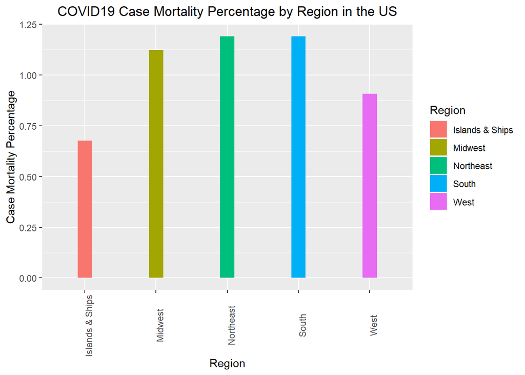

```r
# Visualize Case Mortality by region in the US

us_by_region %>% ggplot(aes(x=Region, y=deaths_per_100_cases, fill=Region)) + geom_bar(stat="identity", width=0.2)+theme(axis.text.x=element_text(angle=90))+ labs(title=str_c("COVID19 Case Mortality Percentage by Region in the US"),y="Case Mortality Percentage") + theme(plot.title = element_text(hjust = 0.5))
```

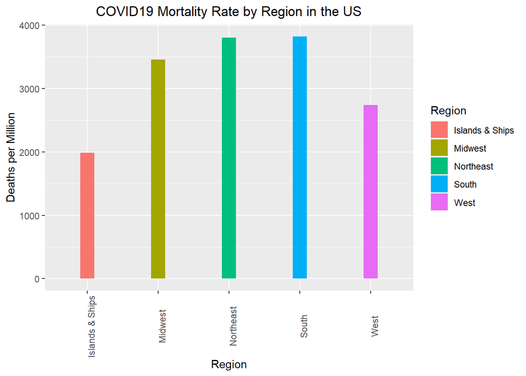

```r
# Visualize Deaths/million by region in the US

us_by_region %>% ggplot(aes(x=Region, y=deaths_per_million, fill=Region)) + geom_bar(stat="identity", width=0.2)+theme(axis.text.x=element_text(angle=90))+ labs(title=str_c("COVID19 Mortality Rate by Region in the US"),y="Deaths per Million") + theme(plot.title = element_text(hjust = 0.5))
```